# Intro to microsimuation and demo

11 February, 2022

## What is microsimulation

## Introduction

- Inform health policies for complex health and health system problems
- Allows policymakers to examine the results, consequences, and benefits of a policy
- Implemented the areas of cancer treatment, obesity, and chronic diseases
- Employed by Canadian agencies (Statistics Canada, Health Canada), project future incidence and prevalence of risk factors and diseases
- Population Health Model (POHEM) Son Canadian population

## Individual-based state-transition

- Model the individual-based state-transition and outcomes
- Monte Carlo (MC) simulation methods
- Stochastic variation of state-transition and individual characteristics
- Simulate the impact of interventions or policies on individual trajectories
- Outcomes can be generated for each individual (e.g. health cost, Quality Adjusted Life Years (QALYs)), estimate the distribution of an outcome
- Flexibility, the transition probabilities can depend on the history prior to that cycle

## Health states and transition probabilities

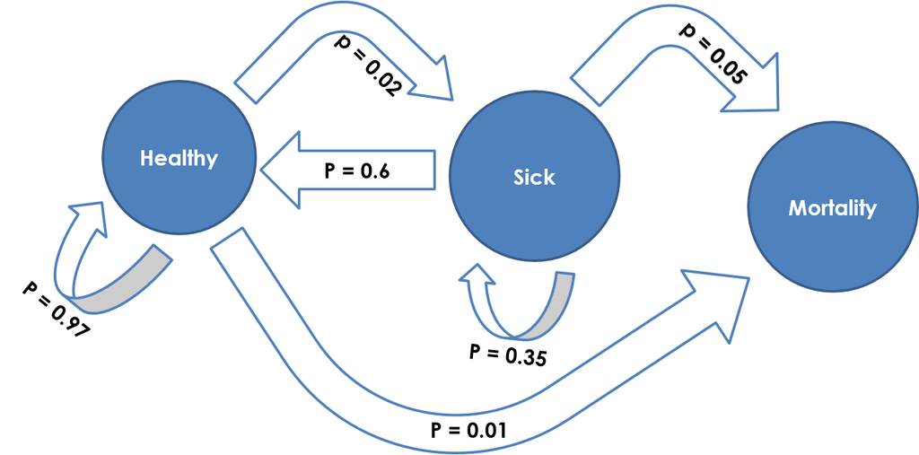

- Transition probabilites (or risk) can be derived from multi-state model or survival models

## Model parameters

- Population size
- Transition probabilities between health states
- Number of cycles
- Individual characteristics

## Model output

### Individual-based state transition

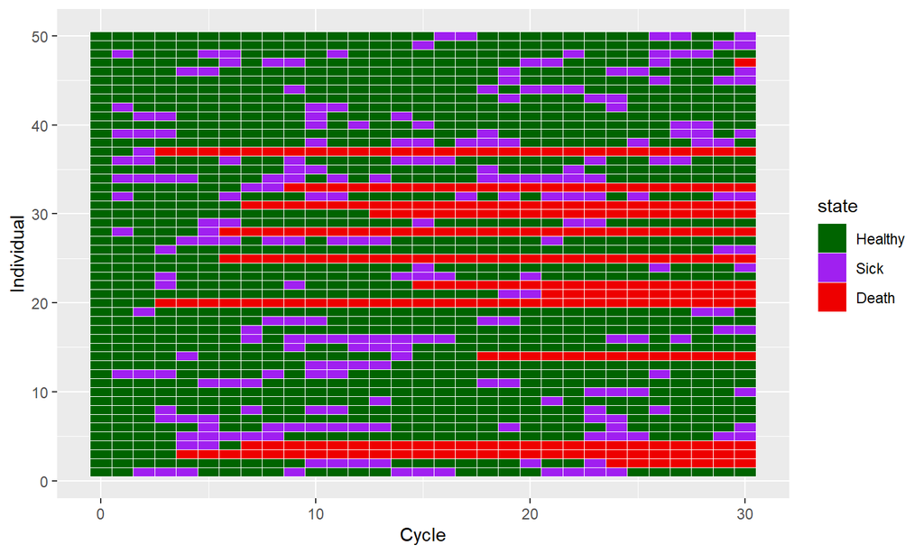

The number health states (Healthy, Sick, Death) per cycle or per individual can be summarised.

### Other health outcomes

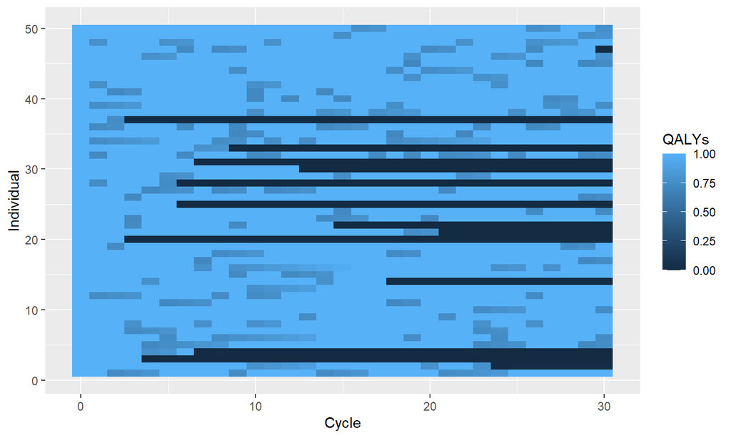

Similarly, the QALYs per cycle or per individual can be summarised.

### Trace the transition probabilites at each cycle

[output not shown]

## Live demo

## CCHS data snapshot and survey weights

|  | Age group | Sex | Education | Income (personal) | Income (household) | Ethnicity | Marital Status | Urban/Rural | WTS_S (survey weight) |
| --- | --- | --- | --- | --- | --- | --- | --- | --- | --- |
| 1 | 40-49 | Male | Secondary school grad | $30,000 TO $39,999 | $50,000 TO $59,999 | NA | Married | Rural | 161.86 |
| 2 | 60-69 | Female | Post-secondary grad | $60,000 TO $79,999 | $100k or more | White | Married | Rural | 345.57 |
| 3 | 40-49 | Male | Less than secondary | NS | $50,000 TO $59,999 | White | Separated | Rural | 84.85 |
| 4 | 40-49 | Female | Post-secondary grad | $50,000 TO $59,999 | $50,000 TO $59,999 | White | Single/Never Married | Rural | 79.92 |
| 5 | 70-79 | Male | Less than secondary | NS | $40,000 TO $49,999 | White | Married | Rural | 166.31 |
| 6 | 50-59 | Male | Post-secondary grad | NS | $50,000 TO $59,999 | White | Married | Rural | 89.82 |
| 7 | 12-29 | Male | Less than secondary |  | $60,000 TO $79,999 | White | Single/Never Married | Rural | 62.01 |
| 8 | 50-59 | Male | Less than secondary | $30,000 TO $39,999 | $100k or more | White | Single/Never Married | Rural | 198.93 |
| 9 | 60-69 | Male | Less than secondary | $10,000 TO $14,999 | $10,000 TO $14,999 | White | Divorced | Rural | 188.66 |
| 10 | 50-59 | Female | Post-secondary grad | $5,000 TO $9,999 | $5,000 TO $9,999 | White | Divorced | Rural | 110.13 |

[output cut: 40 more lines]

## Select specific stratum

On sex, education-level, and geography

```r
cchs2013_14_Ontario_sub <- cchs2013_14_Ontario %>%
  filter(sex == "Female" & educat == "Less than secondary" & geourcat == "Rural")

# Snapshot on the stratum and survey weights
DT::datatable(cchs2013_14_Ontario_sub[,c('agecat','sex','educat','geourcat','WTS_S')], rownames = FALSE,
              colnames=c("Age", "Sex", "Education", "Geography", "WTS_S (survey weights)"),
              options = list(pageLength = 10))
```

| Age | Sex | Education | Geography | WTS_S (survey weights) |
| --- | --- | --- | --- | --- |
| 12-29 | Female | Less than secondary | Rural | 108.97 |
| 70-79 | Female | Less than secondary | Rural | 121.28 |
| 12-29 | Female | Less than secondary | Rural | 199.81 |
| 12-29 | Female | Less than secondary | Rural | 143.92 |
| 12-29 | Female | Less than secondary | Rural | 142.94 |
| 70-79 | Female | Less than secondary | Rural | 103.08 |
| 80+ | Female | Less than secondary | Rural | 53.48 |
| 80+ | Female | Less than secondary | Rural | 178.28 |
| 12-29 | Female | Less than secondary | Rural | 73.15 |
| 30-39 | Female | Less than secondary | Rural | 31.21 |

[output cut: 1142 more lines]

```r
# Sum of survey weights, that's the survey weighted population
wts_pop <- sum(cchs2013_14_Ontario_sub$WTS_S)

cat('Population =',wts_pop)
```

```
## Population = 176156.8
```